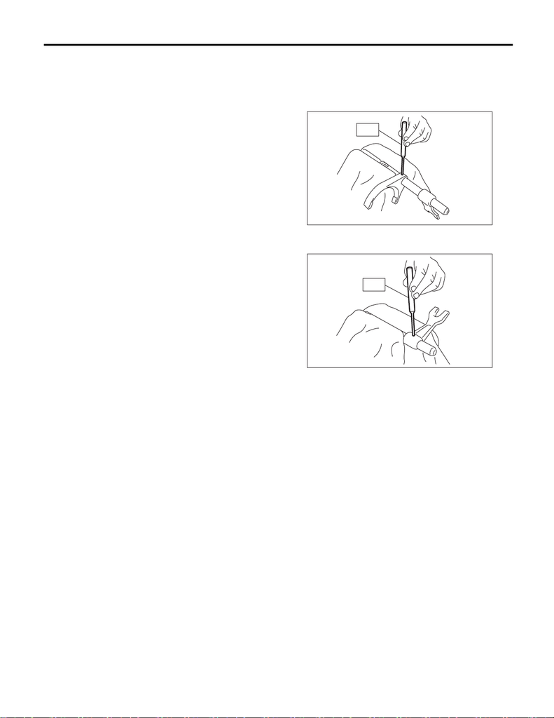

6MT(TY85)-105

Shifter Fork and Rod

MANUAL TRANSMISSION AND DIFFERENTIAL

24.Shifter Fork and Rod

A: REMOVAL

1) Remove the manual transmission assembly

from the vehicle. <Ref. to 6MT(TY85)-31, REMOV-

AL, Manual Transmission Assembly.>

2) Prepare the transmission for overhaul. <Ref. to

6MT(TY85)-38, Preparation for Overhaul.>

3) Remove the neutral position switch, back-up

light switch and harness. <Ref. to 6MT(TY85)-41,

REMOVAL, Neutral Position Switch.> <Ref. to

6MT(TY85)-40, REMOVAL, Back-up Light

Switch.>

4) Remove the extension case. <Ref. to

6MT(TY85)-42, REMOVAL, Extension Case.>

5) Remove the transfer driven gear. <Ref. to

6MT(TY85)-54, REMOVAL, Transfer Driven

Gear.>

6) Remove the center differential. <Ref. to

6MT(TY85)-56, REMOVAL, Center Differential.>

7) Remove the transmission case. <Ref. to

6MT(TY85)-57, REMOVAL, Transmission Case.>

8) Remove the individual gear assemblies. <Ref. to

6MT(TY85)-63, REMOVAL, Main Shaft Assem-

bly.>

B: INSTALLATION

1) Install the individual gear assemblies all at once.

<Ref. to 6MT(TY85)-64, INSTALLATION, Main

Shaft Assembly.>

2) Install the transmission case. <Ref. to

6MT(TY85)-59, INSTALLATION, Transmission

Case.>

3) Install the center differential. <Ref. to

6MT(TY85)-56, INSTALLATION, Center Differen-

tial.>

4) Install the transfer driven gear. <Ref. to

6MT(TY85)-54, INSTALLATION, Transfer Driven

Gear.>

5) Install the extension case. <Ref. to 6MT(TY85)-

42, INSTALLATION, Extension Case.>

6) Install the neutral position switch, back-up light

switch and harness. <Ref. to 6MT(TY85)-41, IN-

STALLATION, Neutral Position Switch.> <Ref. to

6MT(TY85)-40, INSTALLATION, Back-up Light

Switch.>

7) Install the manual transmission assembly to the

vehicle. <Ref. to 6MT(TY85)-33, INSTALLATION,

Manual Transmission Assembly.>

C: DISASSEMBLY

1. REVERSE SHIFTER FORK

1) Remove the reverse fork using the ST.

ST 398791700 REMOVER

2) Remove the reverse shifter arm using the ST.

ST 398791700 REMOVER

MT-00680

ST

MT-00681

ST

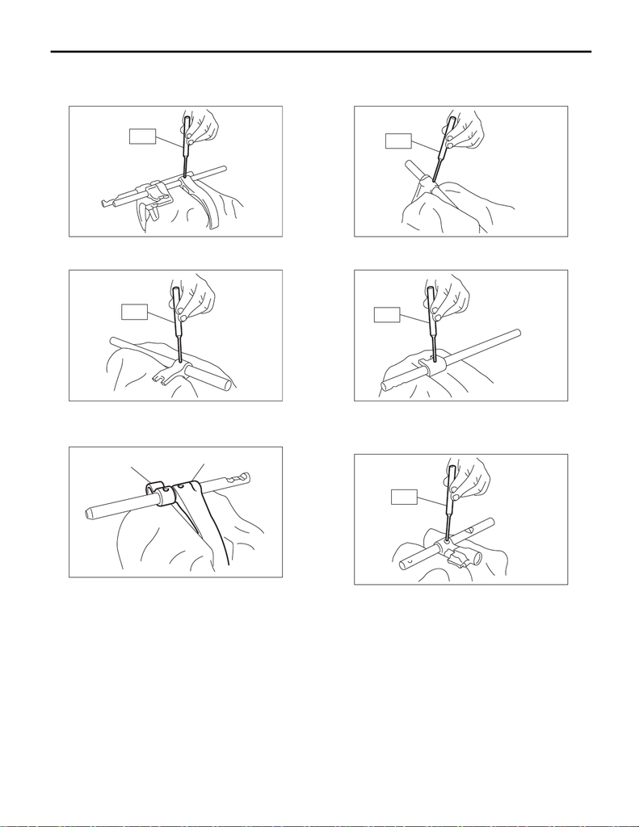

6MT(TY85)-106

Shifter Fork and Rod

MANUAL TRANSMISSION AND DIFFERENTIAL

2. 1ST-2ND, 3RD-4TH SHIFTER FORK

1) Using the ST, remove the 3rd-4th shifter fork.

ST 398791700 REMOVER

2) Using the ST, remove the 3rd-4th shifter arm.

ST 398791700 REMOVER

3) Using the ST, remove the 1st-2nd shifter arm

and 1st-2nd shifter fork.

ST 398791700 REMOVER

3. 5TH-6TH SHIFTER FORK

1) Using the ST, remove the 5th-6th shifter fork.

ST 398791700 REMOVER

2) Using the ST, remove the 5th-6th shifter arm.

ST 398791700 REMOVER

4. SHIFTER ARM SHAFT

Remove the selector arm using the ST.

ST 398791700 REMOVER

(A) 1st-2nd shifter arm

(B) 1st-2nd shifter fork

MT-00682

ST

MT-00683

ST

MT-03144

(A)

(B)

MT-00685

ST

MT-00686

ST

MT-01095

ST

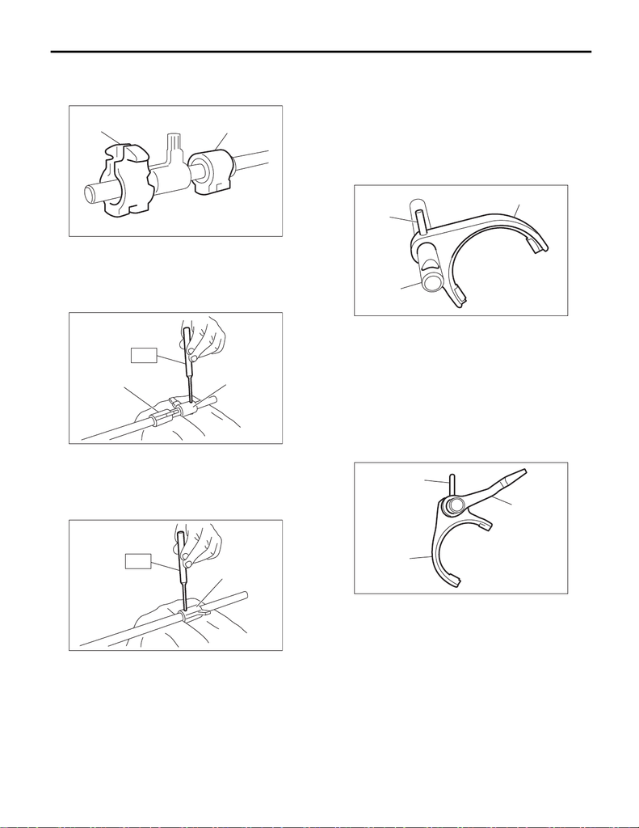

6MT(TY85)-107

Shifter Fork and Rod

MANUAL TRANSMISSION AND DIFFERENTIAL

5. STRIKING ROD

1) Remove the reverse interlock block and the in-

terlock block from the striking rod.

2) Remove the reverse interlock arm using the ST.

ST 398791700 REMOVER

3) Remove the interlock arm using the ST.

ST 398791700 REMOVER

D: ASSEMBLY

1. REVERSE SHIFTER FORK

1) Using the ST, install the reverse fork.

ST 398791700 REMOVER

NOTE:

• Confirm that the reverse shifter fork and rod are

installed in the proper direction.

• Use a new straight pin.

2) Using the ST, install the reverse shifter arm.

ST 398791700 REMOVER

NOTE:

• Confirm that the reverse shifter arm and rod are

installed in the proper direction.

• Use a new straight pin.

(A) Reverse interlock block

(B) Interlock block

(A) Reverse interlock arm

(B) Interlock arm

(A) Interlock arm

MT-00688

(A)

(B)

MT-00689

(A)

(B)

ST

MT-00690

(A)

ST

(A) Reverse shifter fork

(B) Reverse fork rod

(C) Straight pin

(A) Reverse shifter fork

(B) Reverse shifter arm

(C) Straight pin

MT-00691

(C)

(B)

(A)

MT-00692

(C)

(B)

(A)

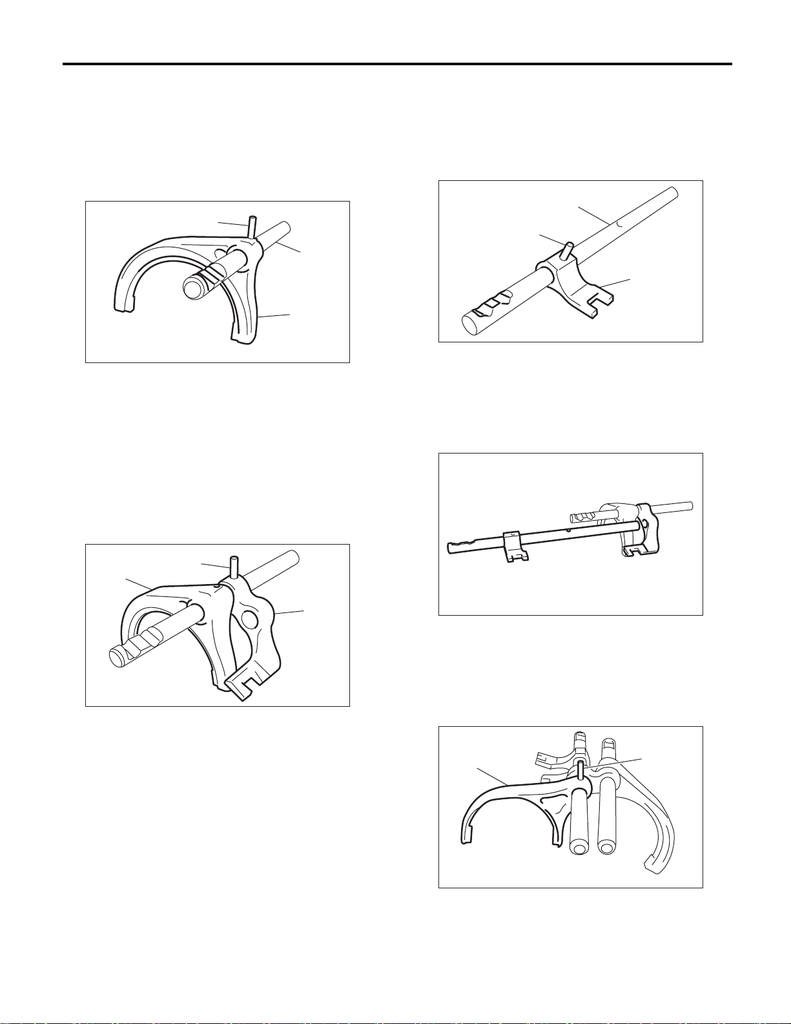

6MT(TY85)-108

Shifter Fork and Rod

MANUAL TRANSMISSION AND DIFFERENTIAL

2. 1ST-2ND, 3RD-4TH SHIFTER FORK

1) Using the ST, install the 1st-2nd shifter fork.

ST 398791700 REMOVER

NOTE:

• Make sure that the 1st-2nd shifter fork and rod

are installed in the correct direction.

• Use a new straight pin.

2) Using the ST, install the 1st-2nd shifter arm.

ST 398791700 REMOVER

NOTE:

• Make sure that the 1st-2nd shifter arm and fork

are installed in the correct direction.

• Use a new straight pin.

3) Using the ST, install the 3rd-4th shifter arm.

ST 398791700 REMOVER

NOTE:

• Make sure that the 3rd-4th shifter arm and rod

are installed in the correct direction.

• Use a new straight pin.

4) Attach the 3rd-4th fork rod to the 1st-2nd shifter

arm.

5) Using the ST, install the 3rd-4th shifter fork.

ST 398791700 REMOVER

NOTE:

• Make sure that the 3rd-4th shifter fork is installed

in the correct direction.

• Use a new straight pin.

(A) 1st-2nd shifter fork

(B) 1st-2nd fork rod

(C) Straight pin

(A) 1st-2nd shifter fork

(B) 1st-2nd shifter arm

(C) Straight pin

MT-03145

(C)

(B)

(A)

MT-03146

(C)

(B)

(A)

(A) 3rd-4th shifter rod

(B) 3rd-4th shifter arm

(C) Straight pin

(A) 3rd-4th shifter fork

(B) Straight pin

MT-03147

(C)

(B)

(A)

MT-03148

MT-01737

(B)

(A)

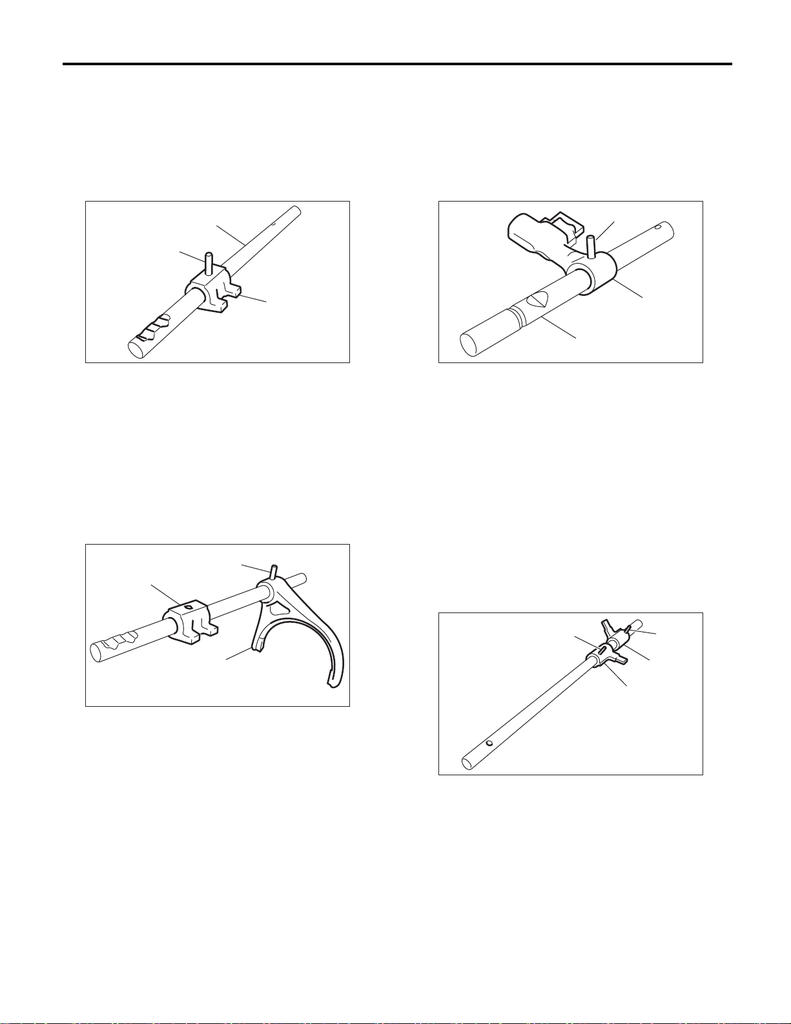

6MT(TY85)-109

Shifter Fork and Rod

MANUAL TRANSMISSION AND DIFFERENTIAL

3. 5TH-6TH SHIFTER FORK

1) Using the ST, install the 5th-6th shifter arm.

ST 398791700 REMOVER

NOTE:

• Make sure that the 5th-6th shifter arm and rod

are installed in the correct direction.

• Use a new straight pin.

2) Using the ST, install the 5th-6th shifter fork.

ST 398791700 REMOVER

NOTE:

• Make sure that the 5th-6th shifter fork and arm

are installed in the correct direction.

• Use a new straight pin.

4. SHIFTER ARM SHAFT

Using the ST, install the selector arm.

ST 398791700 REMOVER

NOTE:

• Confirm that the selector arm and shaft are in-

stalled in the proper direction.

• Use a new straight pin.

5. STRIKING ROD

1) Using the ST, install the reverse interlock arm

and interlock arm.

ST 398791700 REMOVER

NOTE:

• Confirm that the reverse interlock arm and rod

are installed in the proper direction.

• Confirm that the interlock arm and rod are in-

stalled in the proper direction.

• Use a new straight pin.

(A) 5th-6th shifter arm

(B) 5th-6th fork rod

(C) Straight pin

(A) 5th-6th shifter fork

(B) 5th-6th shifter arm

(C) Straight pin

MT-03149

(C)

(B)

(A)

MT-03150

(C)

(B)

(A)

(A) Shifter arm shaft

(B) Selector arm

(C) Straight pin

(A) Reverse interlock arm

(B) Interlock arm

(C) Straight pin

MT-03151

(B)

(A)

(C)

MT-00701

(C)

(C)

(B)

(A)

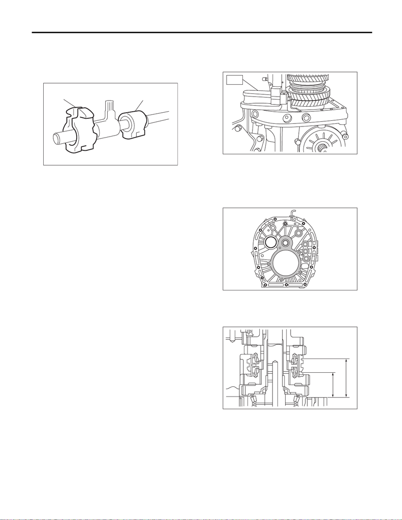

6MT(TY85)-110

Shifter Fork and Rod

MANUAL TRANSMISSION AND DIFFERENTIAL

2) Attach the reverse interlock block and interlock

block to the striking rod.

NOTE:

Confirm that the reverse interlock block and inter-

lock block are installed in the proper direction.

E: INSPECTION

1) Check the shift shaft and shift rod for damage.

Replace if damaged.

2) Repair or replace the gearshift mechanism if ex-

cessively worn, bent or defective in any way.

F: ADJUSTMENT

1. 1ST-2ND FORK ROD SELECTION

NOTE:

In the following conditions, perform the procedures

below.

• Replacement of the 1st and 2nd driven gear

• 1st and 2nd synchro ring assembly replacement

• Adapter plate replacement

• Driven shaft replacement

• 1st-2nd synchronizer hub and coupling sleeve

assembly replacement.

1) Insert the drive pinion assembly into the adapter

plate.

NOTE:

Confirm that the thrust bearing outer race has not

been removed and the drive pinion is not lifted.

2) Set the height gauge to the adapter plate. Lower

the height gauge indicator to the mating surface of

the adapter plate and case, and set to zero points.

ST 18853AA000 HEIGHT GAUGE

NOTE:

• The adapter plate will be the base point for the

measurement. Use a scraper to remove any gasket

material remaining on the end face.

• During measurement, do not place the height

gauge in the shaded area shown in the figure.

3) Select the main shaft snap ring. <Ref. to

6MT(TY85)-75, ADJUSTMENT, Main Shaft As-

sembly.>

4) Measure “B1” and “B2” as shown in the figure.

(A) Reverse interlock block

(B) Interlock block

MT-00688

(A)

(B)

MT-00582

ST

MT-00583

MT-00979

B1

B2

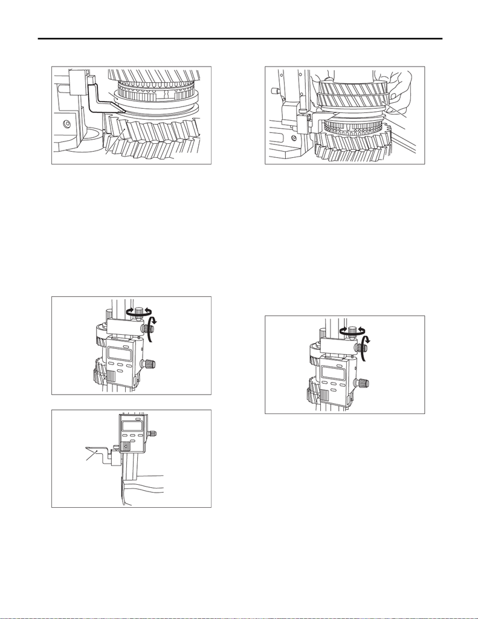

6MT(TY85)-111

Shifter Fork and Rod

MANUAL TRANSMISSION AND DIFFERENTIAL

5) Shift down the 1st-2nd coupling sleeve all the

way to the 1st driven gear side, and measure “B1”.

NOTE:

• Set the height gauge indicator near the measure-

ment target, and lock dial (1) as shown in the figure.

Turn dial (2), and set the indicator to the 1st side

end surface of the coupling sleeve.

• Turn approximately 72° at a time, and measure

the coupling sleeve in 5 locations. Round down the

2 highest and 2 lowest measurement values. The

remaining center value is used as the measure-

ment value.

6) Set the height gauge indicator upside down.

7) Shift up the 1st-2nd coupling sleeve all the way

to the 2nd driven gear side, and measure “B2”.

NOTE:

• Set the height gauge indicator near the measure-

ment target, and lock dial (1) as shown in the figure.

Turn dial (2), and set the indicator to the 2nd side

end surface of the sleeve.

• The measurement is to be performed with two

persons, while holding the coupling sleeve straight.

• Turn approximately 72° at a time, and measure

the coupling sleeve in 5 locations. Round down the

2 highest and 2 lowest measurement values. The

remaining center value is used as the measure-

ment value.

(A) 1st driven gear

(B) 1st-2nd coupling sleeve

(A) Indicator

MT-00702

(A)

(B)

MT-00585

(2)

(1)

MT-00703

(A)

(A) 2nd driven gear

(B) 1st-2nd coupling sleeve

MT-00704

(A)

(B)

MT-00585

(2)

(1)

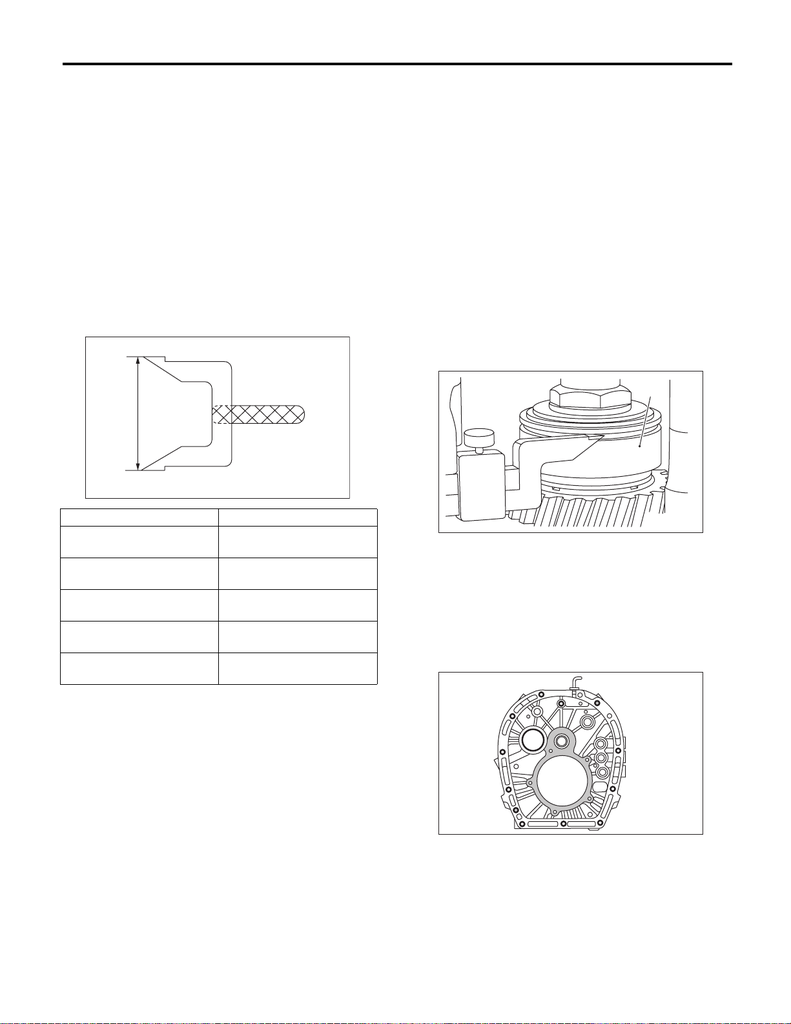

6MT(TY85)-112

Shifter Fork and Rod

MANUAL TRANSMISSION AND DIFFERENTIAL

8) According to both of the measurements, calcu-

late the neutral position of the 1st-2nd coupling

sleeve. From the following calculation, select a fork

rod which matches the calculated value.

Calculation: T = (B1 + B2) / 2

T: 1st-2nd coupling sleeve center position

B1: Height from the adapter plate end to the cou-

pling sleeve end, when shifted to 1st gear

B2: Measured height from the adapter plate end to

the sleeve end, when shifted to 2nd gear: +55 mm

(2.17 in)

NOTE:

Attach the indicator upside down in comparison to

the setting procedures for the zero point. Add “d1”

[Value: 55 mm (2.17 in)] from the figure below to

“B2”, and measure “B2”.

2. 3RD-4TH FORK ROD SELECTION

NOTE:

In the following conditions, perform the procedures

below.

• Main shaft replacement

• 3rd, and 3rd to 6th drive gear and bushing re-

placement

• 3rd, and 3rd to 6th synchro assembly replace-

ment

• 3rd-4th synchronizer hub and coupling sleeve

assembly replacement

1) Insert the main shaft assembly into the adapter

plate.

2) Set the height gauge to the adapter plate. Lower

the height gauge indicator to the top surface of the

snap ring groove, and set to the zero point on the

upper side of the main rear bearing.

ST 18853AA000 HEIGHT GAUGE

NOTE:

• The height gauge will be set on the adapter plate

during the measurement. Use a scraper to remove

any gasket material remaining on the end face.

• During measurement, do not place the height

gauge in the shaded area shown in the figure.

T mm (in) Lot No. (marking)

62.58 — 62.78

(2.4638 — 2.4717)

32801AA370 (5)

62.78 — 62.98

(2.4717 — 2.4795)

32801AA380 (4)

62.98 — 63.18

(2.4795 — 2.4874)

32801AA390 (2)

63.18 — 63.38

(2.4874 — 2.4953)

32801AA400 (1)

63.38 — 63.58

(2.4953 — 2.5031)

32801AA410 (3)

MT-00705

d1

(A) Ball bearing

MT-00706

(A)

MT-00583

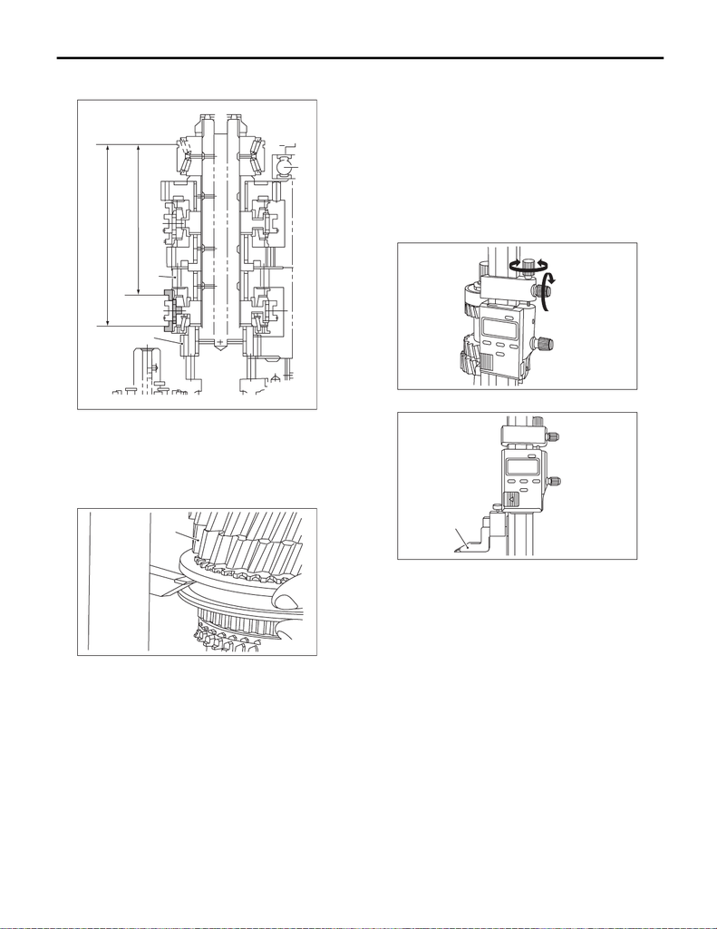

6MT(TY85)-113

Shifter Fork and Rod

MANUAL TRANSMISSION AND DIFFERENTIAL

3) Use a height gauge to measure “C1” and “C2” as

shown in the figure.

(1) Shift up the 3rd-4th coupling sleeve all the

way to the 4th drive gear side, and measure

“C2”.

NOTE:

• Set the height gauge indicator near the measure-

ment target, and lock dial (1) as shown in the figure.

• Turn dial (2), and set the indicator to the 4th side

end surface of the coupling sleeve.

• The measurement is to be performed with two

persons, while holding the coupling sleeve straight.

• Turn approximately 72° at a time, and measure

the coupling sleeve in 5 locations. Round down the

2 highest and 2 lowest measurement values. The

remaining center value is used as the measure-

ment value.

(2) Set the height gauge indicator upside down.

(A) 3rd drive gear

(B) 4th drive gear

(A) 4th drive gear

MT-00707

C1

C2

(A)

(B)

MT-00708

(A)

(A) Indicator

MT-00585

(2)

(1)

MT-00710

(A)

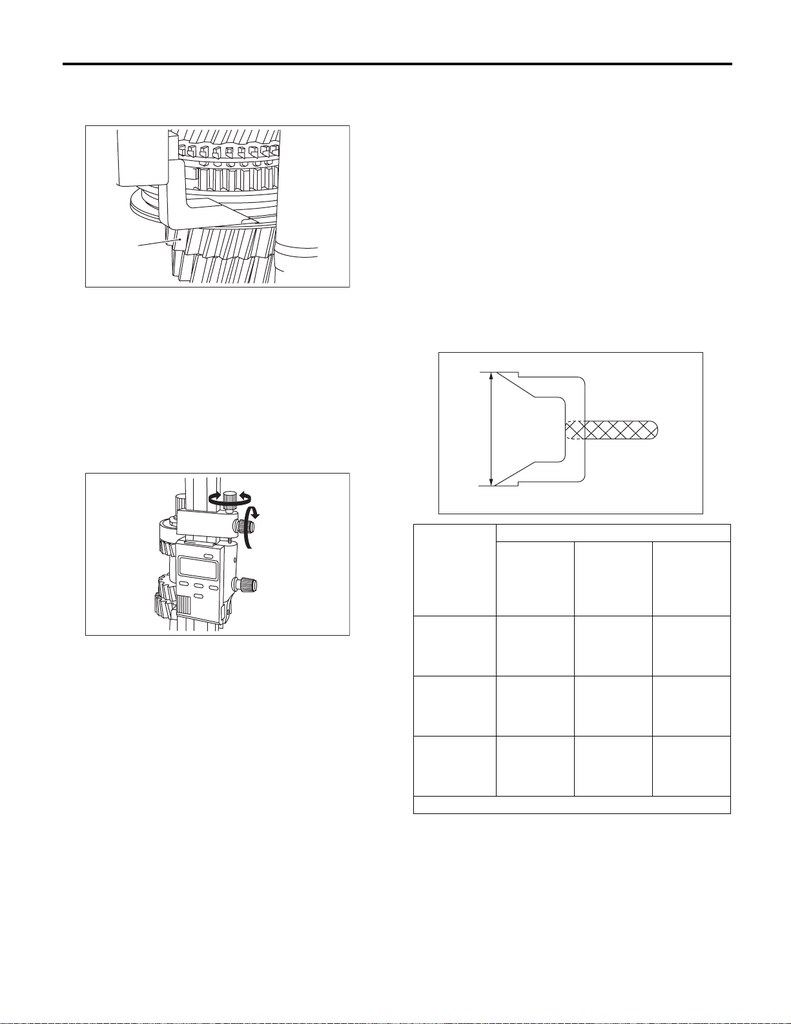

6MT(TY85)-114

Shifter Fork and Rod

MANUAL TRANSMISSION AND DIFFERENTIAL

(3) Shift down the 3rd-4th coupling sleeve all

the way to the 3rd drive gear side, and measure

“C1”.

NOTE:

• Set the height gauge indicator near the measure-

ment target, and lock dial (1) as shown in the figure.

Turn dial (2), and set the indicator to the 3rd side

end surface of the sleeve.

• Turn approximately 72° at a time, and measure

the sleeve in 5 locations. Round down the 2 highest

and 2 lowest measurement values. The remaining

center value is used as the measurement value.

4) According to both of the measurements, calcu-

late the neutral position of the 3rd-4th sleeve. From

the following calculation, select a fork rod which

matches the calculated value.

Calculation: T = (C1 + C2) / 2

T: 3rd-4th sleeve center position

C1: Measured depth from the main shaft rear bear-

ing snap ring groove to the sleeve end, when shift-

ed to 3rd gear: +55 mm (2.17 in)

C2: Measured depth from the main shaft rear bear-

ing snap ring groove to the sleeve end, when shift-

ed to 4th gear

NOTE:

Attach the indicator upside down in comparison to

the setting procedures for the zero point. Add “d1”

[Value: 55 mm (2.17 in)] from the figure below to

“C1”, and measure “C1”.

(A) 3rd drive gear

MT-00711

(A)

MT-00585

(2)

(1)

T mm (in)

Lot No. (marking)

M.SFT

Snap ring

805072010

[t = 1.65 mm

(0.065 in)]

M.SFT

Snap ring

805072011

[t = 1.95 mm

(0.077 in)]

M.SFT

Snap ring

805072012

[t = 2.25 mm

(0.089 in)]

137.22 —

137.52

(5.4024 —

5.4142)

32809AA240

(none)

32809AA250

(2)

32809AA260

(4)

137.52 —

137.82

(5.4142 —

5.4260)

32809AA230

(1)

32809AA240

(none)

32809AA250

(2)

137.82 —

138.12

(5.4260 —

5.4379)

32809AA220

(3)

32809AA230

(1)

32809AA240

(none)

T = Thickness

MT-00705

d1

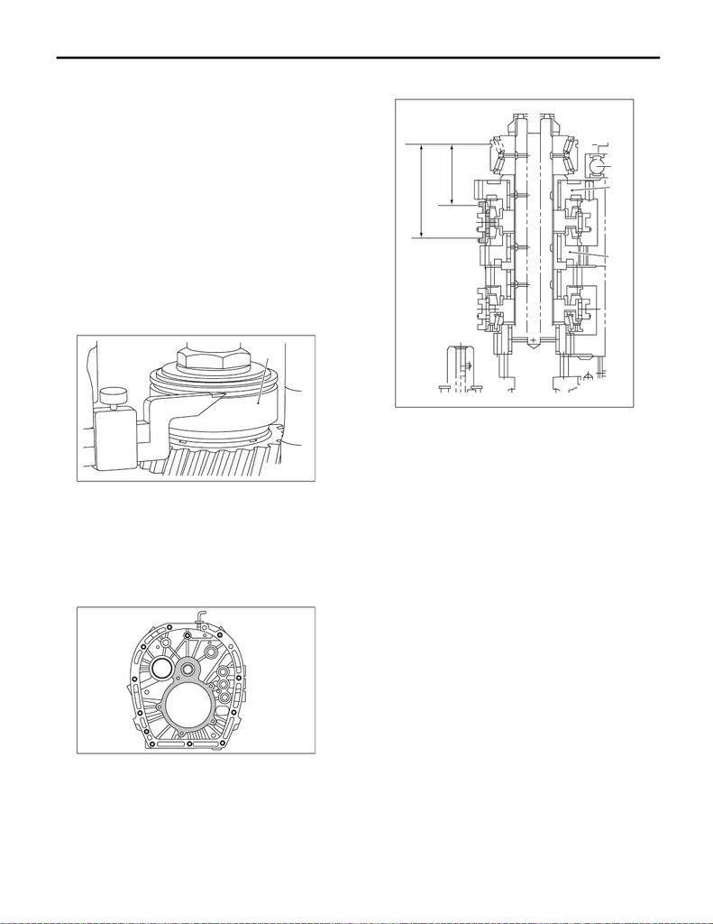

6MT(TY85)-115

Shifter Fork and Rod

MANUAL TRANSMISSION AND DIFFERENTIAL

3. 5TH-6TH FORK ROD SELECTION

NOTE:

In the following conditions, perform the procedures

below.

• Main shaft replacement

• 3rd to 6th drive gear and bushing replacement

• 3rd to 6th synchro ring assembly replacement

• 3rd-4th synchronizer hub and coupling sleeve

assembly replacement

• 5th-6th synchronizer hub and coupling sleeve

assembly replacement

1) Insert the main shaft assembly into the adapter

plate.

2) Set the height gauge to the adapter plate. Lower

the height gauge indicator to the upper face of the

snap ring groove or the upper side of the main rear

bearing. Set to zero point.

ST 18853AA000 HEIGHT GAUGE

NOTE:

• The height gauge will be set on the adapter plate

during the measurement. Use a scraper to remove

any gasket material remaining on the end face.

• During measurement, do not place the height

gauge in the shaded area shown in the figure.

3) Use a height gauge to measure “D1” and “D2” as

shown in the figure.

(A) Ball bearing

MT-00706

(A)

MT-00583

(A) 5th drive gear

(B) 6th drive gear

MT-00712

D1

D2

(A)

(B)

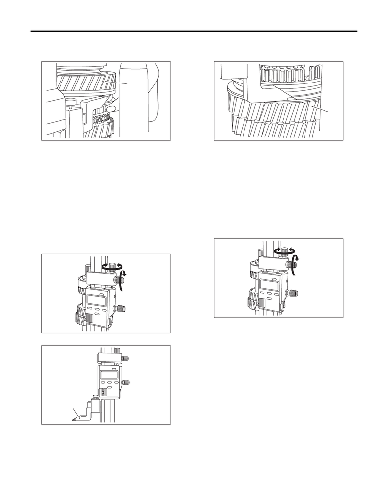

6MT(TY85)-116

Shifter Fork and Rod

MANUAL TRANSMISSION AND DIFFERENTIAL

(1) Shift up the 5th-6th coupling sleeve all the

way to the 6th drive gear side, and measure

“D2”.

NOTE:

• Set the height gauge indicator near the measure-

ment target, and lock dial (1) as shown in the figure.

Turn dial (2), and set the indicator to the 6th side

end surface of the coupling sleeve.

• The measurement is to be performed with two

persons, while holding the coupling sleeve straight.

• Turn approximately 72° at a time, and measure

the coupling sleeve in 5 locations. Round down the

2 highest and 2 lowest measurement values. The

remaining center value is used as the measure-

ment value.

(2) Set the height gauge indicator upside down.

(3) Shift down the 5th-6th coupling sleeve all

the way to the 5th drive gear side, and measure

“D1”.

NOTE:

• Set the height gauge indicator near the measure-

ment target, and lock dial (1) as shown in the figure.

Turn dial (2), and set the indicator to the 5th side

end surface of the coupling sleeve.

• Turn approximately 72° at a time, and measure

the coupling sleeve in 5 locations. Round down the

2 highest and 2 lowest measurement values. The

remaining center value is used as the measure-

ment value.

(A) 6th drive gear

(A) Indicator

MT-00713

(A)

MT-00585

(2)

(1)

MT-00710

(A)

(A) 5th drive gear

MT-00714

(A)

MT-00585

(2)

(1)

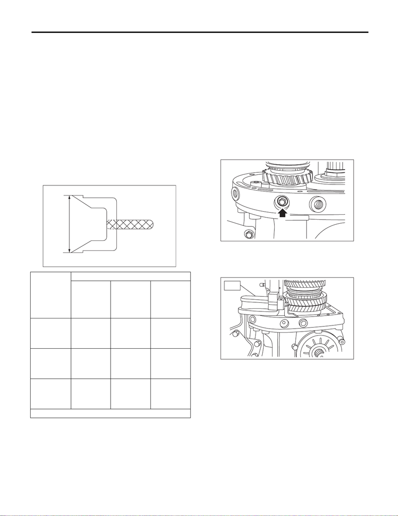

6MT(TY85)-117

Shifter Fork and Rod

MANUAL TRANSMISSION AND DIFFERENTIAL

4) According to both of the measurements, calcu-

late the neutral position of the 5th-6th coupling

sleeve. From the following calculation, select a fork

rod which matches the calculated value.

Calculation: T = (D1 + D2) / 2

T: 5th-6th coupling sleeve center position

D1: Measured length from the shaft rear bearing

snap ring groove to the coupling sleeve groove

end, when shifted to 5th gear [Value: +55 mm (2.17

in)]

D2: Measured length from the main shaft rear bear-

ing snap ring groove to the coupling sleeve groove

end, when shifted to 6th gear

NOTE:

Attach the indicator upside down in comparison to

the setting procedures for the zero point. Add “d1”

[Value: 55 mm (2.17 in)] from the figure below to

“D1”, and measure “D1”.

4. REVERSE FORK ROD SELECTION

NOTE:

In the following conditions, perform the procedures

below.

• Reverse idler gear replacement.

• Reverse idler gear No. 2 replacement.

• Adapter plate replacement.

• Base replacement.

1) Insert the reverse idler gear assembly into the

adapter plate.

2) Tighten the reverse idler gear shaft attachment

bolts.

Tightening torque:

25 N·m (2.5 kgf-m, 18.4 ft-lb)

3) Set the height gauge to the adapter plate. Lower

the height gauge indicator to the mating surface of

the adapter plate and case, and set to zero points.

ST 18853AA000 HEIGHT GAUGE

T mm (in)

Lot No. (marking)

M.SFT

Snap ring

805072010

[t = 1.65 mm

(0.065 in)]

M.SFT

Snap ring

805072011

[t = 1.95 mm

(0.077 in)]

M.SFT

Snap ring

805072012

[t = 2.25 mm

(0.089 in)]

64.12 —

64.42

(2.5244 —

2.5362)

32945AA110

(none)

32945AA120

(2)

32945AA130

(4)

64.42 —

64.72

(2.5362 —

2.5480)

32945AA100

(1)

32945AA110

(none)

32945AA120

(2)

64.72 —

65.02

(2.5480 —

2.5598)

32945AA090

(3)

32945AA100

(1)

32945AA110

(none)

T = Thickness

MT-00705

d1

MT-00546

MT-00582

ST

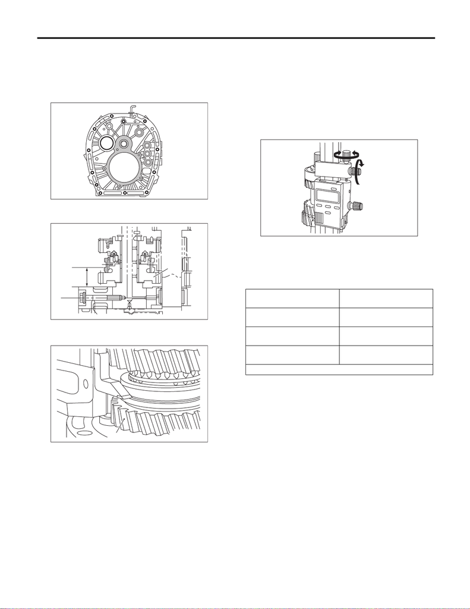

6MT(TY85)-118

Shifter Fork and Rod

MANUAL TRANSMISSION AND DIFFERENTIAL

NOTE:

• The adapter plate will be the base point for the

measurement. Use a scraper to remove any gasket

material remaining on the end face.

• During measurement, do not place the height

gauge in the shaded area shown in the figure.

4) Shift the reverse coupling sleeve to the reverse

idler gear No. 2, and measure “T”.

NOTE:

• Set the height gauge indicator near the measure-

ment target, and lock dial (1) as shown in the figure.

Turn dial (2), and set the indicator to the end face of

the reverse coupling sleeve side.

• Turn approximately 72° at a time, and measure

the coupling sleeve in 5 locations. Round down the

2 highest and 2 lowest measurement values. The

remaining center value is used as the measure-

ment value.

5) Calculate the neutral position of the reverse cou-

pling sleeve according to the measurement. From

the following calculation, select a fork rod which

matches the calculated value.

Calculation: T + 4.8 mm (0.189 in)

(A) Reverse idler gear No. 2

(A) Reverse idler gear No. 2

MT-00583

MT-00715

(A)

T

MT-00716

(A)

T + 4.8 mm (0.189 in)

mm (in)

Lot No. (marking)

33.50 — 33.80

(1.3189 — 1.3307)

32816AA190 (1)

33.80 — 34.10

(1.3307 — 1.3425)

32816AA200 (none)

34.10 — 34.40

(1.3425 — 1.3543)

32816AA210 (2)

T = Thickness

MT-00585

(2)

(1)